# TCC - Aplicação

A. Schmidt

23 de outubro de 2017

## Instala e carrega os pacotes usados

```r
list.of.packages <- c("ggplot2", "metRology", "reshape2", "gridExtra","knitr", "stargazer", "foreign", "dplyr", "lmtest", "sandwich")
new.packages <- list.of.packages[!(list.of.packages %in% installed.packages()[,"Package"])]
if(length(new.packages)) install.packages(new.packages)
library(ggplot2, quietly = T)
library(metRology, quietly = T)
library(reshape2, quietly = T)
library(gridExtra, quietly = T)
library(knitr, quietly = T)
library(stargazer, quietly = T)
library(foreign, quietly = T)
library(dplyr, quietly = T)
library(lmtest, quietly = T)
library(sandwich, quietly = T)
options(scipen=999)
```

# Leitura e descritivas dos dados

## Arquivo dadosraistisc

```r
dadosraistisc <- read.dta("C:\\Users\\Aishameriane\\Dropbox\\TCC Aisha\\Texto TCC\\TCC\\Códigos - R\\Dados Artigo Bonini\\dadosraistisc.dta")
head(dadosraistisc)
```

```
##   cboocupao2002 cnae20classe vnculoativo3112 escolaridadeaps2005
## 1        212405        26523               1                   7
## 2        212405        26515               1                   7
## 3        212405        26213               1                   7
## 4        212405        26329               1                   7
## 5        212405        26329               1                   7
## 6        212405        26329               1                   7
##   qtdhoracontr idade municpio vlremunmdianom cnae20subclasse sexo tempemp
## 1           40    31   420540        1285.22         2652300    1    10.5
## 2           44    23   420540        2709.75         2651500    1     9.9
## 3            2    30   421660         509.84         2621300    1     0.9
## 4           40    28   420540        4151.76         2632900    1    67.2
## 5           40    24   420540        1829.48         2632900    1    11.6
## 6           40    31   420540        2286.07         2632900    1    37.9
##       salhr   lnsalh idade2 sgc mdio supinc sup mes dout pos
## 1  32.13050 3.469806    961   0    1      0   0   0    0   0
## 2  61.58523 4.120422    529   0    1      0   0   0    0   0
## 3 254.92000 5.540950    900   0    1      0   0   0    0   0
## 4 103.79399 4.642408    784   0    1      0   0   0    0   0
## 5  45.73700 3.822908    576   0    1      0   0   0    0   0
## 6  57.15175 4.045710    961   0    1      0   0   0    0   0
```

```r
glimpse(dadosraistisc)
```

```
## Observations: 4,352
## Variables: 21
## $ cboocupao2002       <int> 212405, 212405, 212405, 212405, 212405, 21...
## $ cnae20classe        <int> 26523, 26515, 26213, 26329, 26329, 26329, ...
## $ vnculoativo3112     <int> 1, 1, 1, 1, 1, 1, 1, 1, 1, 1, 1, 1, 1, 1, ...
## $ escolaridadeaps2005 <int> 7, 7, 7, 7, 7, 7, 8, 8, 8, 8, 8, 8, 8, 9, ...
## $ qtdhoracontr        <int> 40, 44, 2, 40, 40, 40, 44, 44, 44, 44, 30,...
## $ idade               <int> 31, 23, 30, 28, 24, 31, 34, 28, 31, 37, 21...
## $ municpio            <int> 420540, 420540, 421660, 420540, 420540, 42...
## $ vlremunmdianom      <dbl> 1285.22, 2709.75, 509.84, 4151.76, 1829.48...
## $ cnae20subclasse     <int> 2652300, 2651500, 2621300, 2632900, 263290...
## $ sexo                <int> 1, 1, 1, 1, 1, 1, 1, 1, 1, 1, 1, 1, 1, 1, ...
## $ tempemp             <dbl> 10.5, 9.9, 0.9, 67.2, 11.6, 37.9, 21.7, 72...
## $ salhr               <dbl> 32.13050, 61.58523, 254.92000, 103.79399, ...
## $ lnsalh              <dbl> 3.469806, 4.120422, 5.540950, 4.642408, 3....
## $ idade2              <dbl> 961, 529, 900, 784, 576, 961, 1156, 784, 9...
## $ sgc                 <dbl> 0, 0, 0, 0, 0, 0, 0, 0, 0, 0, 0, 0, 0, 0, ...
## $ mdio                <dbl> 1, 1, 1, 1, 1, 1, 0, 0, 0, 0, 0, 0, 0, 0, ...
## $ supinc              <dbl> 0, 0, 0, 0, 0, 0, 1, 1, 1, 1, 1, 1, 1, 0, ...
## $ sup                 <dbl> 0, 0, 0, 0, 0, 0, 0, 0, 0, 0, 0, 0, 0, 1, ...
## $ mes                 <dbl> 0, 0, 0, 0, 0, 0, 0, 0, 0, 0, 0, 0, 0, 0, ...
## $ dout                <dbl> 0, 0, 0, 0, 0, 0, 0, 0, 0, 0, 0, 0, 0, 0, ...
## $ pos                 <dbl> 0, 0, 0, 0, 0, 0, 0, 0, 0, 0, 0, 0, 0, 0, ...
```

```r
tail(dadosraistisc)
```

```
##      cboocupao2002 cnae20classe vnculoativo3112 escolaridadeaps2005
## 4347        212420        62031               0                   9
## 4348        212420        62031               0                   9
## 4349        212420        62031               0                   9
## 4350        212420        62015               0                   9
## 4351        212420        62015               0                   9
## 4352        212420        62015               0                   9
##      qtdhoracontr idade municpio vlremunmdianom cnae20subclasse sexo
## 4347           44    22   420240         805.97         6203100    2
## 4348           44    24   420240         810.51         6203100    2
## 4349           44    22   420240         866.74         6203100    2
## 4350           44    30   420910        1849.22         6201500    2
## 4351           44    32   420910        3199.99         6201500    2
## 4352           44    24   420910        2167.61         6201500    2
##      tempemp    salhr   lnsalh idade2 sgc mdio supinc sup mes dout pos
## 4347     6.7 18.31750 2.907857    484   0    0      0   1   0    0   0
## 4348    13.0 18.42068 2.913474    576   0    0      0   1   0    0   0
## 4349    11.2 19.69864 2.980549    484   0    0      0   1   0    0   0
## 4350    52.7 42.02773 3.738329    900   0    0      0   1   0    0   0
## 4351     1.8 72.72704 4.286713   1024   0    0      0   1   0    0   0
## 4352    34.8 49.26387 3.897191    576   0    0      0   1   0    0   0
```

```r
# Utiliza a notação decimal
options(scipen=9999)

N <- nrow(dadosraistisc)     # Determina o tamanho da amostra
k <- 7                       # Número de regressores

# Junta as variáveis com o intercepto
dados <- cbind(dadosraistisc$lnsalh, rep(1,N), dadosraistisc[,c(17,18,21,6,14,11,10)])
dados <- as.matrix(dados)
dados <- dados[complete.cases(dados),]
colnames(dados) <- c("lnsalh", "cons", "supinc", "sup", "pos", "idade", "idade2", "tempemp", "sexo")
summary(dados)
```

```
##      lnsalh           cons       supinc            sup
##  Min.   :1.382   Min.   :1   Min.   :0.0000   Min.   :0.0000
##  1st Qu.:3.782   1st Qu.:1   1st Qu.:0.0000   1st Qu.:0.0000
##  Median :4.223   Median :1   Median :0.0000   Median :1.0000
##  Mean   :4.205   Mean   :1   Mean   :0.1613   Mean   :0.7412
##  3rd Qu.:4.596   3rd Qu.:1   3rd Qu.:0.0000   3rd Qu.:1.0000
##  Max.   :7.322   Max.   :1   Max.   :1.0000   Max.   :1.0000
##       pos              idade           idade2          tempemp
##  Min.   :0.00000   Min.   :17.00   Min.   : 289.0   Min.   :  0.10
##  1st Qu.:0.00000   1st Qu.:26.00   1st Qu.: 676.0   1st Qu.:  9.70
##  Median :0.00000   Median :29.00   Median : 841.0   Median : 16.95
##  Mean   :0.01386   Mean   :30.57   Mean   : 988.4   Mean   : 34.55
##  3rd Qu.:0.00000   3rd Qu.:34.00   3rd Qu.:1156.0   3rd Qu.: 36.92
##  Max.   :2.00000   Max.   :72.00   Max.   :5184.0   Max.   :433.40
##       sexo
##  Min.   :1.000
##  1st Qu.:1.000
##  Median :1.000
##  Mean   :1.239
##  3rd Qu.:1.000
##  Max.   :2.000
```

```r
sd(dados[,1])
```

```
## [1] 0.6930944
```

```r
## Sorteio dos valores para serem previstos
#round(runif(6,min = 1,max = 4328),0)
# 3997 1266 3624 1239 1156  809

# Acabei escolhendo no olho para ter bastante perfis diferentes
## Separa em dois bancos de dados
dados[c(3997, 1266, 3624, 809, 3196, 1, 661, 2007, 670, 2405),]
```

```
##        lnsalh cons supinc sup pos idade idade2 tempemp sexo
## 4010 4.649568    1      0   1   0    29    841    31.1    1
## 1268 4.723517    1      0   1   0    27    729     6.1    1
## 3634 4.772060    1      0   1   0    25    625    17.9    1
## 810  3.897958    1      0   1   0    20    400    16.9    1
## 3204 3.320792    1      1   0   0    22    484    19.9    2
## 1    3.469806    1      0   0   0    31    961    10.5    1
## 662  4.171071    1      0   1   0    27    729    19.9    1
## 2015 3.768433    1      0   1   0    23    529    19.2    2
## 671  3.299270    1      0   1   0    19    361    13.9    1
## 2413 6.696866    1      0   0   2    37   1369    32.5    2
```

```r
novos_dados <- dados[c(3997, 1266, 3624, 809, 3196, 1, 661, 2007, 670, 2405),]
dados_antigos <- dados[-c(3997, 1266, 3624, 809, 3196, 1, 661, 2007, 670, 2405),]

dados_antigos2 <- data.frame(dados_antigos)

dados_antigos2$sexo[dados_antigos2$sexo == 1] <- 0
dados_antigos2$sexo[dados_antigos2$sexo == 2] <- 1
dados_antigos2$pos[dados_antigos2$pos == 2] <- 1

novos_dados2 <- data.frame(novos_dados)

novos_dados2$sexo[novos_dados2$sexo == 1] <- 0
novos_dados2$sexo[novos_dados2$sexo == 2] <- 1
novos_dados2$pos[novos_dados2$pos == 2] <- 1

summary(dados_antigos2[,"idade"])
```

```
##    Min. 1st Qu.  Median    Mean 3rd Qu.    Max.
##   17.00   26.00   29.00   30.58   34.00   72.00
```

```r
sd(dados_antigos2[,"idade"])
```

```
## [1] 7.353564
```

```r
nrow(dados_antigos2)
```

```
## [1] 4318
```

```r
summary(dados_antigos2[,"idade2"])
```

```
##    Min. 1st Qu.  Median    Mean 3rd Qu.    Max.
##   289.0   676.0   841.0   989.1  1156.0  5184.0
```

```r
sd(dados_antigos2[,"idade2"])
```

```
## [1] 527.3192
```

```r
summary(dados_antigos2[,"tempemp"])
```

```
##    Min. 1st Qu.  Median    Mean 3rd Qu.    Max.
##    0.10    9.70   16.90   34.59   37.10  433.40
```

```r
sd(dados_antigos2[,"tempemp"])
```

```
## [1] 54.25795
```

```r
summary(dados_antigos2[,"lnsalh"])
```

```
##    Min. 1st Qu.  Median    Mean 3rd Qu.    Max.
##   1.382   3.783   4.223   4.205   4.596   7.322
```

```r
sd(dados_antigos2[,"lnsalh"])
```

```
## [1] 0.6923215
```

```r
table(dados_antigos2[,"sexo"])
```

```
##
##    0    1
## 3285 1033
```

```r
round(table(dados_antigos2[,"sexo"])/nrow(dados_antigos2), 4)
```

```
##
##      0      1
## 0.7608 0.2392
```

```r
table(dados_antigos2[,"supinc"])
```

```
##
##    0    1
## 3621  697
```

```r
round(table(dados_antigos2[,"supinc"])/nrow(dados_antigos2), 4)
```

```
##
##      0      1
## 0.8386 0.1614
```

```r
table(dados_antigos2[,"sup"])
```

```
##
##    0    1
## 1117 3201
```

```r
round(table(dados_antigos2[,"sup"])/nrow(dados_antigos2), 4)
```

```
##
##      0      1
## 0.2587 0.7413
```

```r
table(dados_antigos2[,"pos"])
```

```
##
##    0    1
## 4289   29
```

```r
round(table(dados_antigos2[,"pos"])/nrow(dados_antigos2), 4)
```

```
##
##      0      1
## 0.9933 0.0067
```

```r
# Numeração das variáveis

# 4 - escolaridadeaps2005
# 5 - qtdhoracontr
# 6 - idade
# 10 - sexo
# 11 - tempemp
# 12 - salhr
# 13 - lnsalh
# 14 - idade2
# 16 - mdio
# 17 - supinc
# 18 - sup
# 19 - mes
# 20 - dout
# 21 - pos
```

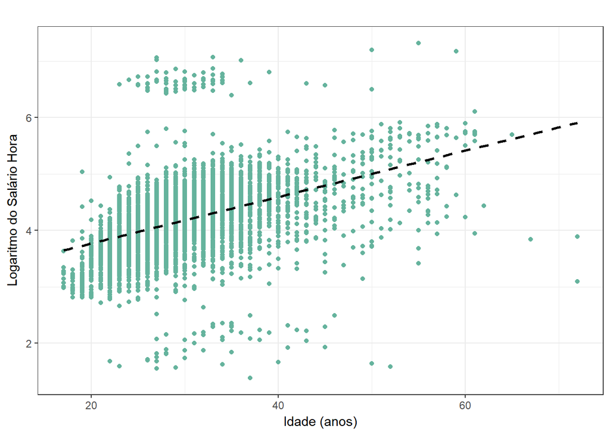

```r
# Gráficos

# Idade
p <- ggplot(as.data.frame(dados_antigos), aes(idade, lnsalh)) +
  geom_point(color = "#65b39d") +
  geom_smooth(method=lm, se=FALSE, linetype="dashed", color="black") +
  labs(title="", x = "Idade (anos)", y= "Logaritmo do Salário Hora") +
  theme_bw()
p
```

```r
pdf(file="C:\\Users\\Aishameriane\\Dropbox\\TCC Aisha\\Texto TCC\\TCC\\Figuras\\Fig-4.002.pdf", width = 6, height = 3)
p
dev.off()
```

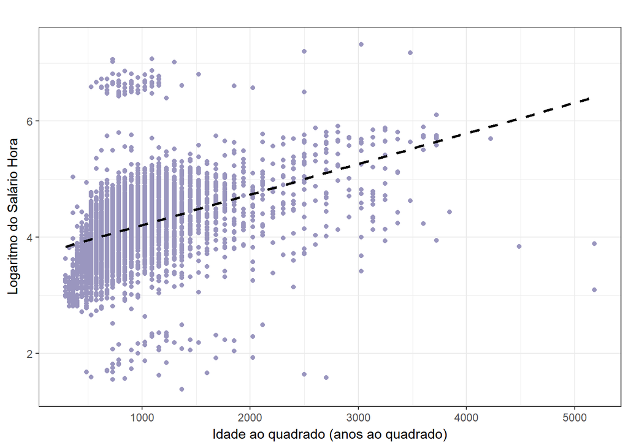

```r
# Idade^2
p <- ggplot(as.data.frame(dados_antigos), aes(idade2, lnsalh)) +
  geom_point(color = "#9a96bf") +
  geom_smooth(method=lm, se=FALSE, linetype="dashed", color="black") +
  labs(title="", x = "Idade ao quadrado (anos ao quadrado)", y= "Logaritmo do Salário Hora") +
  theme_bw()
p
```

```r
pdf(file="C:\\Users\\Aishameriane\\Dropbox\\TCC Aisha\\Texto TCC\\TCC\\Figuras\\Fig-4.003.pdf", width = 6, height = 3)
p
dev.off()
```

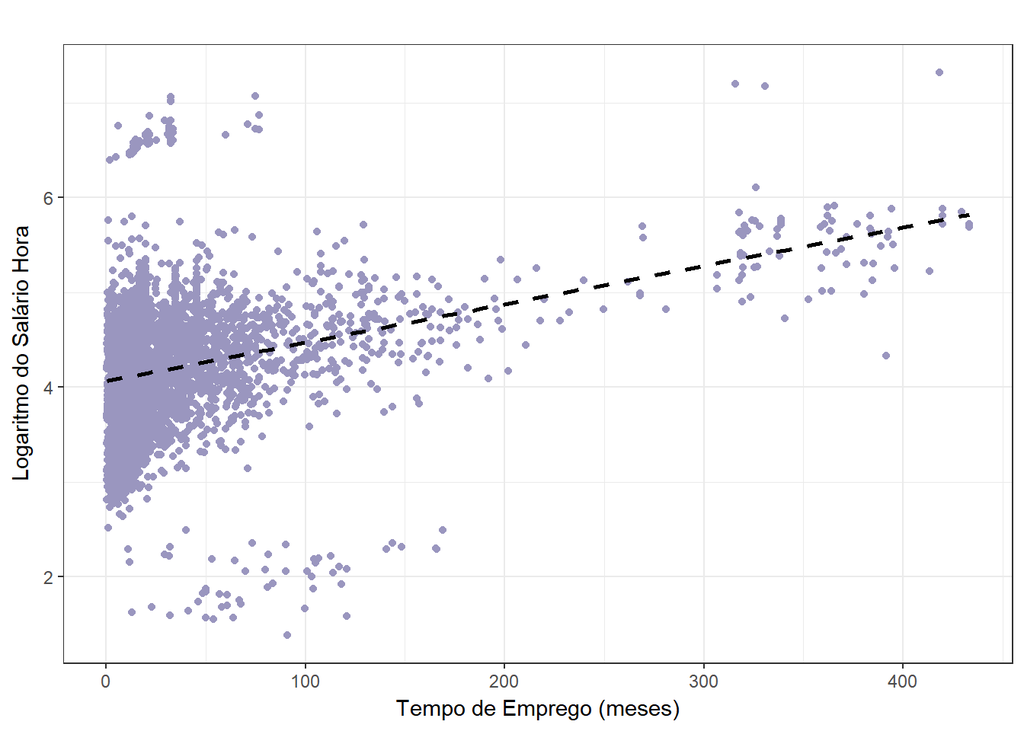

```r
# Tempo de emprego
p <- ggplot(as.data.frame(dados_antigos), aes(tempemp, lnsalh)) +
  geom_point(color = "#9a96bf") +
  geom_smooth(method=lm, se=FALSE, linetype="dashed", color="black") +
  labs(title="", x = "Tempo de Emprego (meses)", y= "Logaritmo do Salário Hora") +
  theme_bw()
p
```

```r
pdf(file="C:\\Users\\Aishameriane\\Dropbox\\TCC Aisha\\Texto TCC\\TCC\\Figuras\\Fig-4.004.pdf", width = 6, height = 3)
p
dev.off()
```

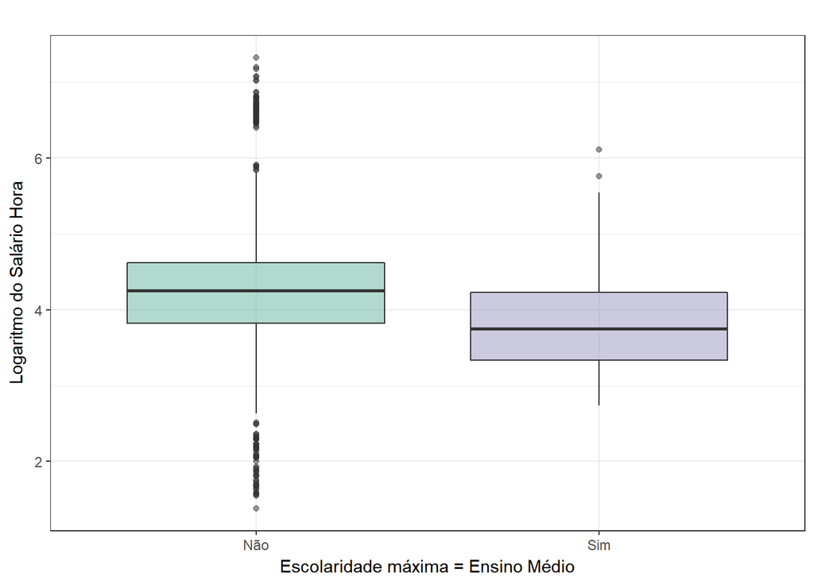

```r
# Ensino médio
p <- ggplot(as.data.frame(dadosraistisc), aes(factor(mdio),lnsalh, fill=factor(mdio))) +
  geom_boxplot(alpha = 0.5) +
  ggtitle("") +
  scale_fill_manual(values = c("#65b39d", "#9a96bf"), name = "", labels = c("Não", "Sim")) +
  scale_x_discrete(breaks=c(0,1), labels = c("Não", "Sim")) +
  labs(title="", y = "Logaritmo do Salário Hora", x= "Escolaridade máxima = Ensino Médio") +
  theme_bw()
p<-p + theme(legend.position="none")
p
```

```r
pdf(file="C:\\Users\\Aishameriane\\Dropbox\\TCC Aisha\\Texto TCC\\TCC\\Figuras\\Fig-4.005.pdf", width = 6, height = 3)
p
dev.off()
```

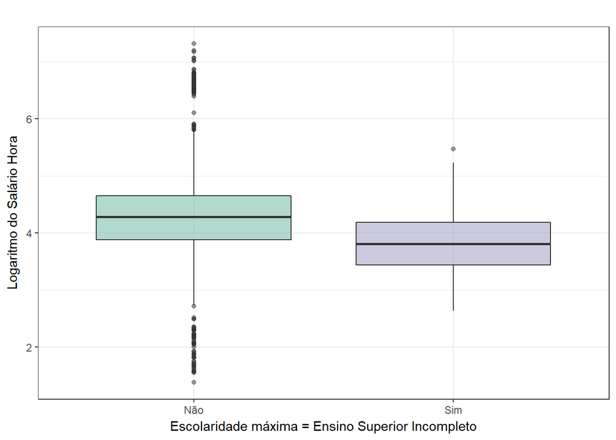

```r
# Superior Incompleto
p <- ggplot(as.data.frame(dados_antigos), aes(factor(supinc),lnsalh, fill=factor(supinc))) +
  geom_boxplot(alpha = 0.5) +
  ggtitle("") +
  scale_fill_manual(values = c("#65b39d", "#9a96bf"), name = "", labels = c("Não", "Sim")) +
  scale_x_discrete(breaks=c(0,1), labels = c("Não", "Sim")) +
  labs(title="", y = "Logaritmo do Salário Hora", x= "Escolaridade máxima = Ensino Superior Incompleto") +
  theme_bw()
p <- p + theme(legend.position="none")
p
```

```r
pdf(file="C:\\Users\\Aishameriane\\Dropbox\\TCC Aisha\\Texto TCC\\TCC\\Figuras\\Fig-4.006.pdf", width = 6, height = 3)
p
dev.off()
```

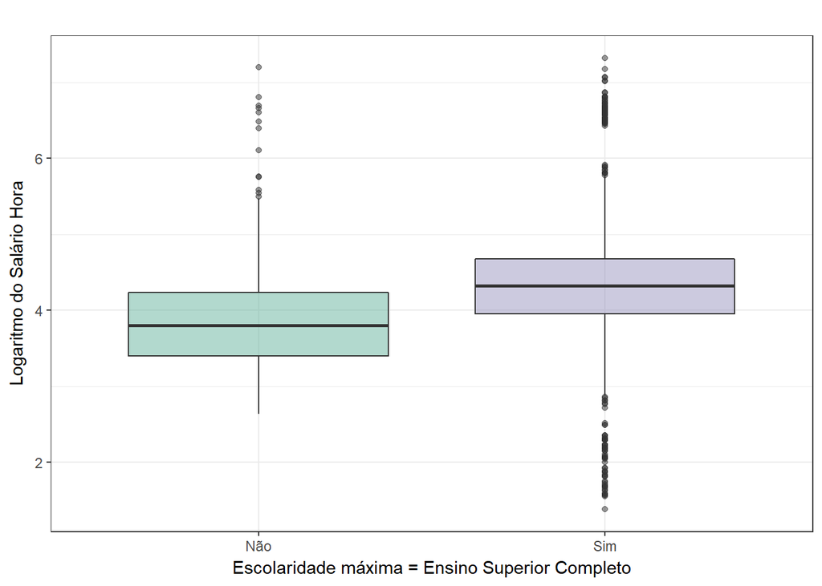

```r
# Superior
p <- ggplot(as.data.frame(dados_antigos), aes(factor(sup),lnsalh, fill=factor(sup))) +
  geom_boxplot(alpha = 0.5) +
  ggtitle("") +
  scale_fill_manual(values = c("#65b39d", "#9a96bf"), name = "", labels = c("Não", "Sim")) +
  scale_x_discrete(breaks=c(0,1), labels = c("Não", "Sim")) +
  labs(title="", y = "Logaritmo do Salário Hora", x= "Escolaridade máxima = Ensino Superior Completo") +
  theme_bw()
p <-p + theme(legend.position="none")
p
```

```r
pdf(file="C:\\Users\\Aishameriane\\Dropbox\\TCC Aisha\\Texto TCC\\TCC\\Figuras\\Fig-4.007.pdf", width = 6, height = 3)
p
dev.off()
```

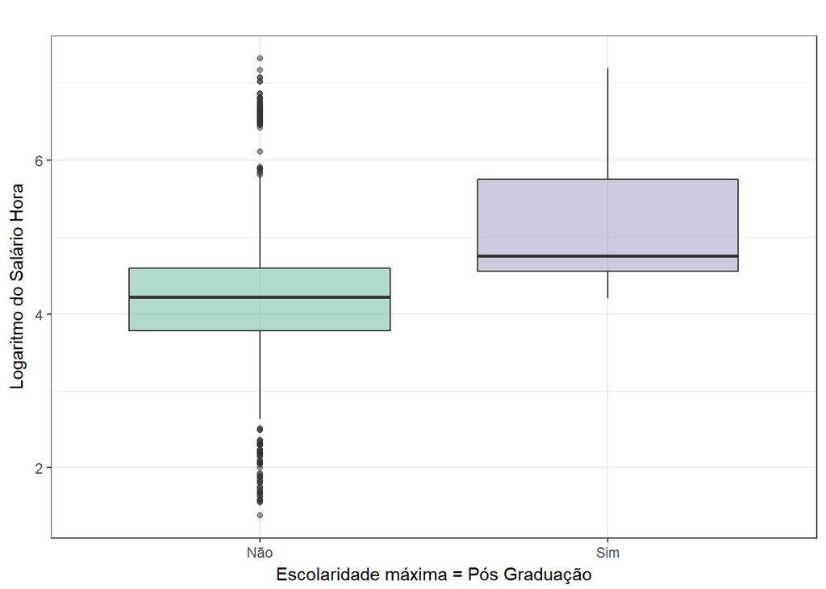

```r
# Pós graduação
p <- ggplot(as.data.frame(dados_antigos), aes(factor(pos),lnsalh, fill=factor(pos))) +
  geom_boxplot(alpha = 0.5) +
  ggtitle("") +
  scale_fill_manual(values = c("#65b39d", "#9a96bf"), name = "", labels = c("Não", "Sim")) +
  scale_x_discrete(breaks=c(0,2), labels = c("Não", "Sim")) +
  labs(title="", y = "Logaritmo do Salário Hora", x= "Escolaridade máxima = Pós Graduação") +
  theme_bw()
p <- p + theme(legend.position="none")
p
```

```r
pdf(file="C:\\Users\\Aishameriane\\Dropbox\\TCC Aisha\\Texto TCC\\TCC\\Figuras\\Fig-4.008.pdf", width = 6, height = 3)
p
dev.off()
```

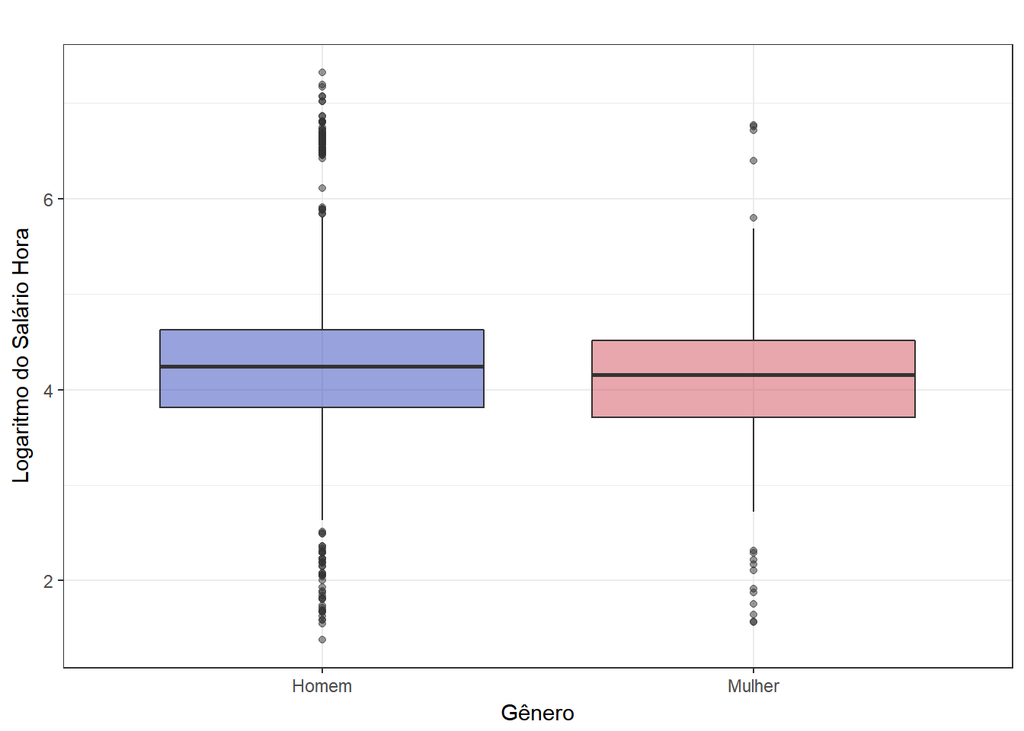

```r
# Gênero
p <- ggplot(as.data.frame(dados_antigos), aes(factor(sexo),lnsalh, fill=factor(sexo))) +
  geom_boxplot(alpha = 0.5) +
  ggtitle("") +
  scale_fill_manual(values = c("#3146bc", "#d14f5a"), name = "", labels = c("Homem", "Mulher")) +
  scale_x_discrete(breaks=c(1,2), labels = c("Homem", "Mulher")) +
  labs(title="", y = "Logaritmo do Salário Hora", x= "Gênero") +
  theme_bw()
p <-p + theme(legend.position="none")
p
```

```r
pdf(file="C:\\Users\\Aishameriane\\Dropbox\\TCC Aisha\\Texto TCC\\TCC\\Figuras\\Fig-4.009.pdf", width = 6, height = 3)
p
dev.off()
```

## Arquivo dadostisc

```r
dadostisc <- read.dta("C:\\Users\\Aishameriane\\Dropbox\\TCC Aisha\\Texto TCC\\TCC\\Códigos - R\\Dados Artigo Bonini\\dadostisc.dta")
head(dadostisc)
glimpse(dadostisc)
summary(dadostisc)

summary(dadostisc[,"idade"])
summary(dadostisc[,"vlremunmdianom"])
summary(dadostisc[,"tempoemprego"])

table(dadostisc[,"ocup"])
table(dadostisc[,"cnaeclasse"])
table(dadostisc[,"vnculoativo3112"])
table(dadostisc[,"escolaridadeapos2005"])
table(dadostisc[,"qtdhoracontr"])
table(dadostisc[,"cnaesubclasse"])
table(dadostisc[,"sexotrabalhador"])
```

## Arquivo dadostisc2

```r
dadostisc2 <- read.dta("C:\\Users\\Aishameriane\\Dropbox\\TCC Aisha\\Texto TCC\\TCC\\Códigos - R\\Dados Artigo Bonini\\dadostisc2.dta")
head(dadostisc2)
glimpse(dadostisc2)
summary(dadostisc2)

summary(dadostisc2[,"idade"])
summary(dadostisc2[,"vlremunmdianom"])
summary(dadostisc2[,"tempoemprego"])

table(dadostisc2[,"cboocupao2002"])
table(dadostisc2[,"cnae20classe"])
table(dadostisc2[,"cnae20subclasse"])
table(dadostisc2[,"vnculoativo3112"])
table(dadostisc2[,"escolaridadeaps2005"])
table(dadostisc2[,"qtdhoracontr"])
table(dadostisc2[,"municpio"])
table(dadostisc2[,"sexotrabalhador"])
```

# Modelo teórico

O modelo proposto é:

# Determinação da priori

Para determinar a priori foram escolhidos como médias os valores estimados por Bonini e Pozzobon (2014) para o estado de Santa Catarina:

- Intercepto: $\beta_0. = 2.07$
- Coef. Superior Incompleto: $\beta_1. = 0.122687$
- Coef. Superior Completo: $\beta_2. = 0.44866$
- Coef. Pós-Graduação: $\beta_3. = 1.070809$
- Coef. Idade: $\beta_4. = 0.128502$
- Coef. Idade$^2$: $\beta_5. = -0.00143$
- Coef. Gênero: $\beta_6. = -0.15366$

Quanto ao erro padrão a priori dos erros, podemos primeiro olhar para a distribuição dos salários hora:

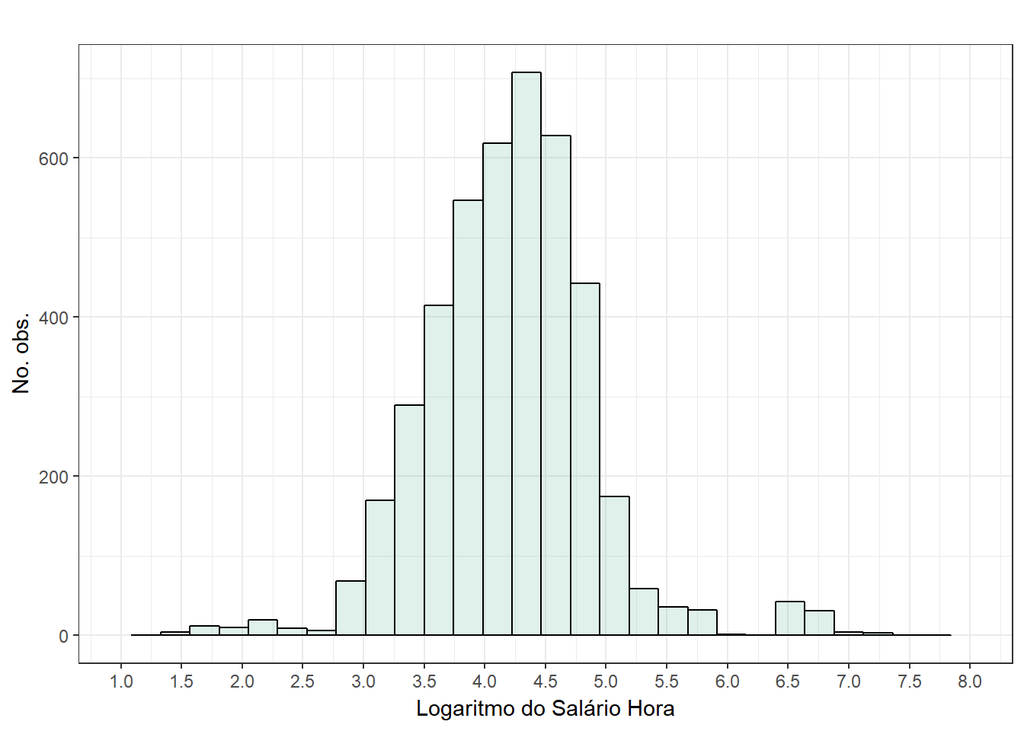

```r
p1 <- ggplot(data = data.frame(dados), aes(dados[,1])) +
  geom_histogram(aes(y = ..count..),
                 alpha = .2, colour = "black", fill = "#65b39d") +
  ggtitle("") +
  labs(title="", y="No. obs.", x="Logaritmo do Salário Hora") +
  scale_x_continuous(breaks = seq(1, 8, 0.5),
                        limits = c(1,8)) +
  scale_colour_brewer(palette="Dark2") +
  theme_bw()

p1
```

```r
# Altura e largura são em inches, default = 7
#pdf(file="C:\\Users\\Aishameriane\\Dropbox\\TCC Aisha\\Texto TCC\\TCC\\Figuras\\Fig-4.001.pdf", width = 6, height = 3)
#p1
#dev.off()
```

Como a maior parte dos valores está concentrada entre 3 e 5.5, pode-se pensar que em $\sigma = 1$. Dado que os erros são normalmente distribuídos com média zero, o valor de $\sigma$ implicará que $95\%$ dos erros será menor que $1.96 1 = $ 1.96, em valor absoluto. Uma vez que $h = \frac{1}{\sigma^2}$, uma priori razoável para $h$ é de $\frac{1}{1} = 1$. Então, $s.^{-2} = 1$.

Pode-se dar um peso grande para a priori através dos graus de liberdade. Quanto mais próximo $\nu.$ for de $N$, maior peso estará sendo dado para este palpite inicial. Para $N = 4328$, pode-se pensar em $\nu. = 44$. De acordo com Koop, isso significa que a priori a respeito de $h$ tem $\nu/N\%$ do peso dos dados, neste caso, 1.02 %.

```r
# Seta uma priori informativa
# * Intercepto = 2.07$
# * Coef. Superior Incompleto  = 0.122687$
# * Coef. Superior Completo = 0.44866$
# * Coef. Pós-Graduação  = 1.070809$
# * Coef. Idade = 0.128502$
# * Coef. Idade$^2$  = -0.00143$
# * Coef. Tempo de emprego: 0.00271
# * Coef. Gênero: $\beta_6. = -0.15366$

b0   <- c(2.07, 0.122687, 0.44866, 1.070809, 0.128502, -0.00143, 0.00271, -0.15366) # Priori Informativa

s02   <- 1  # Desvio padrão dos erros a priori
nu0   <- 44       # Graus de liberdade a priori
h0    <- 1/s02   # Priori para h
stdh0 <- 2/(s02*nu0)

# Para encontrar os elementos da matriz V, utilizamos a fórmula do texto
cons    <- (nu0 * s02)/(nu0-2)
varbeta <- c(100, 100, 100, 100, 100, 100, 100, 100)
V0_in   <- diag(8)*(varbeta/cons) # Matriz de escala da priori
```

## Cálculos a posteriori

```r
conjugada_natural <- function(Y, X, nu0, s20, B0, V0, varargin = NULL) {

  # Cálculo das quantidades de MQO
  N      <- nrow(X)    # Tamanho da amostra a partir da matriz X
  k      <- ncol(X)    # Número de regressores
  nu     <- N-k        # Graus de liberdade
  XX     <- t(matrix(X, ncol = k)) %*% matrix(X, ncol=k)
  iXX    <- solve(XX)
  BMQO   <- iXX %*% (t(X) %*% Y)                           # Beta de MQO
  s2     <- (t(Y-X %*% BMQO) %*% (Y-X %*% BMQO))/nu       # Estimativa não viesada da var dos erros
  CovMQO <- as.numeric(s2) * iXX                          # Matriz de covariância do beta de MQO
  stdMQO <- sqrt(diag(CovMQO))                            # Desvio padrão das estimativas de MQO

  # Parâmetros da posteriori

  nu1 <- nu0 + N # Graus de liberdade
  if (V0 == 0){
    iV0 <- diag(k)*0
  } else {
    iV0 <- solve(V0) # Precisão a posteriori
  }

  iV1   <- iV0 + XX    # Inverso da escala a posteriori
  V1    <- solve(iV1)  # Escala a posteriori
  B1    <- V1 %*% (iV0 %*% B0 + XX %*% BMQO)
  nus21 <- nu0 * s20 + nu * s2

  if (det(iV0) > 0) {
    nus21 <- nus21 + t(BMQO - B0) %*% solve(V0 + iXX) %*% (BMQO - B0) # SQR a posteriori
  } else {
    nus21 <- nus21
  }

  s21 <- nus21/nu1

  # Parâmetros da distribuição posterior marginal beta

  CovB <- V1 * as.numeric(nus21/(nu1-2))  # Variância da distribuição t
  stdB <- sqrt(diag(CovB))    # Desvio padrão da posteriori marginal de beta

  # Calcula os intervalos de maior densidade a posteriori de 95% e 99%

  lim95   <- qt(0.975, nu1) # Valor da t para o quantil 97.5
  lim99   <- qt(0.995, nu1) # Valor da t para o quantil 99.5

  HPDI95  <- round(cbind(B1 - lim95*stdB, B1 + lim95*stdB),4)
  HPDI99  <- round(cbind(B1 - lim99*stdB, B1 + lim99*stdB),4)

  probpos=vector()

  for (i in 1:k){
    tnorm = -B1[i,1]/sqrt(s21*V1[i,i])
    probpos[i] = 1 - pt(tnorm,nu1)
  }

  # Parâmetros da distribuição posterior marginal de h

  h1    <- 1/s21            # Média da distribuição gama que determina h
  h1var <- 2/(nus21)        # Variância da distribuição a posteriori marginal de h

  # Logaritmo da função de verossimilhança marginal

  lmlik <- vector()
  if (det(iV0 > 0)) {
    c <- lgamma(0.5*nu1) +
      0.5*nu0*log(nu0*s20)-lgamma(0.5*nu0)-0.5*N*log(pi) # constante de integração
    lmlik <- c+0.5*log(det(V1)/det(V0)) -0.5*nu1*log(nus21)  # log da veross. marginal
  } else {
    lmlik <- 0
  }

  # Faz previsão de X* é passado como argumento para a função
  if (is.null(varargin) == FALSE) {
    Xestrela   <- varargin
    Yestrela   <- Xestrela %*% B1                          # Previsão Y*
    VYestrela  <- (diag(nrow(Xestrela))+Xestrela %*% V1 %*% t(Xestrela))*as.numeric(s21)  # Matriz de escala da previsão
    Varestrela <- VYestrela * nu1/(nu1 - 2)                # Variância da previsão
    HPDI95prev  <- round(cbind(Yestrela - lim95*diag(Varestrela), Yestrela + lim95*diag(Varestrela)),4)
    HPDI99prev  <- round(cbind(Yestrela - lim99*diag(Varestrela), Yestrela + lim99*diag(Varestrela)),4)
  } else {
    Yestrela    <- NA
    VYestrela   <- NA
    Varestrela  <- NA
    HPDI95prev  <- NA
    HPDI99prev  <- NA
  }

  return(list(B1=B1, V1=V1, stdB=stdB, nu1=nu1, s21=s21, CovB=CovB, h1=h1, h1var=h1var, lmlik = lmlik, HPDI95 = HPDI95, HPDI99 = HPDI99, previsao = Yestrela, varprev = Varestrela, escalaprev = VYestrela, BMQO = BMQO, stdMQO = stdMQO, probpos = probpos, HPDI95prev = HPDI95prev, HPDI99prev= HPDI99prev))
}
```

## Calculando

| (Intercept) | supinc | sup | pos | idade | idade2 | tempemp | sexo |
| --- | --- | --- | --- | --- | --- | --- | --- |
| 0.012 | -0.001 | -0.00001 | -0.0004 | -0.001 | 0.00001 | -0.00000 | -0.0002 |
| -0.001 | 0.001 | 0.001 | 0.001 | -0.00000 | 0.00000 | 0.00000 | -0.00000 |
| -0.00001 | 0.001 | 0.001 | 0.001 | -0.00003 | 0.00000 | 0.00000 | -0.0001 |
| -0.0004 | 0.001 | 0.001 | 0.029 | 0.00000 | -0.00000 | 0.00000 | -0.0001 |
| -0.001 | -0.00000 | -0.00003 | 0.00000 | 0.00004 | -0.00000 | 0.00000 | 0.00000 |
| 0.00001 | 0.00000 | 0.00000 | -0.00000 | -0.00000 | 0 | -0 | -0.00000 |
| -0.00000 | 0.00000 | 0.00000 | 0.00000 | 0.00000 | -0 | 0.00000 | 0.00000 |
| -0.0002 | -0.00000 | -0.0001 | -0.0001 | 0.00000 | -0.00000 | 0.00000 | 0.0004 |

|  | *Dependent variable:* |
| --- | --- |
| supinc | 0.094** |
|  | (0.037) |
| sup | 0.374*** |
|  | (0.032) |
| pos | 1.071*** |
|  | (0.112) |
| idade | 0.120*** |
|  | (0.007) |
| idade2 | -0.001*** |
|  | (0.0001) |
| tempemp | 0.003*** |
|  | (0.0002) |
| sexo | -0.132*** |
|  | (0.021) |
| Constant | 1.493*** |
|  | (0.124) |
| *Note:* | p<0.1; p<0.05; p<0.01 |

t test of coefficients:

```
            Estimate   Std. Error  t value              Pr(>|t|)
```

(Intercept) 1.492581486 0.108607443 13.7429 < 0.00000000000000022 *supinc 0.094125740 0.028408573 3.3133 0.0009297* sup 0.373802948 0.027350213 13.6673 < 0.00000000000000022 *pos 1.071014337 0.169745106 6.3095 0.000000000308030* idade 0.119622529 0.006539478 18.2924 < 0.00000000000000022 *idade2 -0.001315263 0.000094941 -13.8534 < 0.00000000000000022* tempemp 0.002524036 0.000191633 13.1712 < 0.00000000000000022 *sexo -0.132389026 0.018915737 -6.9989 0.000000000002979* — Signif. codes: 0 ‘**’ 0.001 ’**’ 0.01 ’’ 0.05 ‘.’ 0.1 ‘’ 1

Wald test

Model 1: lnsalh ~ supinc + sup + pos + idade + idade2 + tempemp + sexo Model 2: lnsalh ~ 1 Res.Df Df F Pr(>F)  
1 4310  
2 4317 -7 303.4 < 0.00000000000000022 *** — Signif. codes: 0 ‘**’ 0.001 ’**’ 0.01 ’’ 0.05 ‘.’ 0.1 ‘’ 1

| Res.Df | Df | F | Pr(> F) |
| --- | --- | --- | --- |
| 4,310 |  |  |  |
| 4,317 | -7 | 303.402 | 0 |

t test of coefficients:

```
            Estimate   Std. Error  t value              Pr(>|t|)
```

(Intercept) 1.492581486 0.108607443 13.7429 < 0.00000000000000022 *supinc 0.094125740 0.028408573 3.3133 0.0009297* sup 0.373802948 0.027350213 13.6673 < 0.00000000000000022 *pos 1.071014337 0.169745106 6.3095 0.000000000308030* idade 0.119622529 0.006539478 18.2924 < 0.00000000000000022 *idade2 -0.001315263 0.000094941 -13.8534 < 0.00000000000000022* tempemp 0.002524036 0.000191633 13.1712 < 0.00000000000000022 *sexo -0.132389026 0.018915737 -6.9989 0.000000000002979* — Signif. codes: 0 ‘**’ 0.001 ’**’ 0.01 ’’ 0.05 ‘.’ 0.1 ‘’ 1

Wald test

Model 1: lnsalh ~ supinc + sup + pos + idade + idade2 + tempemp + sexo Model 2: lnsalh ~ 1 Res.Df Df F Pr(>F)  
1 4310  
2 4317 -7 303.4 < 0.00000000000000022 *** — Signif. codes: 0 ‘**’ 0.001 ’**’ 0.01 ’’ 0.05 ‘.’ 0.1 ‘’ 1

| V1 | V2 | V3 | V4 | V5 | V6 | V7 | V8 |
| --- | --- | --- | --- | --- | --- | --- | --- |
| Parâmetro | Priori | MQO | stdMQO | Posteriori | std | IC95% | P(Beta > 0) |
| beta_0 | 2.07 | 1.49258 | 0.1238 | 1.49285 | 0.1249 | [1.2481;1.7376] | 1 |
| beta_1 | 0.12 | 0.09413 | 0.0368 | 0.09411 | 0.0371 | [0.0213;0.1669] | 0.99437 |
| beta_2 | 0.45 | 0.3738 | 0.0319 | 0.3738 | 0.0321 | [0.3108;0.4368] | 1 |
| beta_3 | 1.07 | 1.07101 | 0.1124 | 1.07102 | 0.1134 | [0.8487;1.2934] | 1 |
| beta_4 | 0.13 | 0.11962 | 0.0072 | 0.11961 | 0.0073 | [0.1053;0.1339] | 1 |
| beta_5 | -0.00143 | -0.00132 | 0.0001 | -0.00132 | 0.0001 | [-0.0015;-0.0011] | 0 |
| beta_6 | 0.00271 | 0.00252 | 0.0002 | 0.00252 | 0.0002 | [0.0021;0.0029] | 1 |
| beta_7 | -0.15 | -0.13239 | 0.0208 | -0.13239 | 0.021 | [-0.1736;-0.0912] | 0 |

| V1 | V2 | V3 | V4 | V5 |
| --- | --- | --- | --- | --- |
| Valor Real | Est. Bayesiana | Int. Cred. 95% | MQO | IC95% |
| 4.64957 | 4.3078 | [3.6324;4.9832] | 4.3078 | [3.1675;5.4481] |
| 4.72352 | 4.15277 | [3.4773;4.8282] | 4.15276 | [3.01242;5.2931] |
| 4.77206 | 4.0801 | [3.4045;4.7557] | 4.08009 | [2.93967;5.22051] |
| 3.89796 | 3.77543 | [3.099;4.4519] | 3.77539 | [2.63425;4.91653] |
| 3.32079 | 3.49967 | [2.8229;4.1765] | 3.49965 | [2.3582;4.64111] |
| 3.46981 | 3.96341 | [3.2863;4.6405] | 3.96341 | [2.82171;5.10512] |
| 4.17107 | 4.1876 | [3.5121;4.8631] | 4.18759 | [3.04727;5.32792] |
| 3.76843 | 3.83802 | [3.1618;4.5142] | 3.838 | [2.69706;4.97894] |
| 3.29927 | 3.69954 | [3.0228;4.3763] | 3.69949 | [2.55808;4.8409] |
| 6.69687 | 5.13866 | [4.4397;5.8376] | 5.13868 | [3.97867;6.29868] |

png 2

# Verificando o ajuste

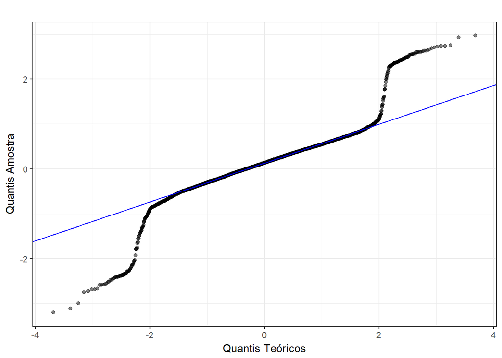

```r
errosbayes <- dados_antigos[,1] - (estimativa$B1[1] + estimativa$B1[2] * dados_antigos[,3] + estimativa$B1[3] * dados_antigos[,4] + estimativa$B1[4] * dados_antigos[,5] + estimativa$B1[5] * dados_antigos[,6] + estimativa$B1[6] * dados_antigos[,7] + estimativa$B1[7] * dados_antigos[,8] + estimativa$B1[8] * dados_antigos[,9])

errosMQO <- dados_antigos[,1] - (estimativa$BMQO[1] + estimativa$BMQO[2] * dados_antigos[,3] + estimativa$BMQO[3] * dados_antigos[,4] + estimativa$BMQO[4] * dados_antigos[,5] + estimativa$BMQO[5] * dados_antigos[,6] + estimativa$BMQO[6] * dados_antigos[,7] + estimativa$BMQO[7] * dados_antigos[,8] + + estimativa$BMQO[8] * dados_antigos[,9])

#qqnorm(errosMQO)
#qqnorm(errosbayes)

#hist(errosbayes)
#hist(errosMQO)

ggQQ <- function(vetor) # argument: a linear model
{
    y <- quantile(vetor[!is.na(vetor)], c(0.25, 0.75))
    x <- qnorm(c(0.25, 0.75))
    slope <- diff(y)/diff(x)
    int <- y[1L] - slope * x[1L]
    d <- data.frame(resids = vetor)
    p <- ggplot(d, aes(sample=resids)) +
       stat_qq(alpha = 0.5) +
       geom_abline(slope = slope, intercept = int, color="blue")+
       ggtitle("") +
       labs(title="", y = "Quantis Amostra", x= "Quantis Teóricos") +
       theme_bw()

    return(p)
}

ggQQ(errosbayes)
```

```r
# Altura e largura são em inches, default = 7
pdf(file="C:\\Users\\Aishameriane\\Dropbox\\TCC Aisha\\Texto TCC\\TCC\\Figuras\\Fig-4.014.pdf", width = 6, height = 3)
ggQQ(errosbayes)
dev.off()
```

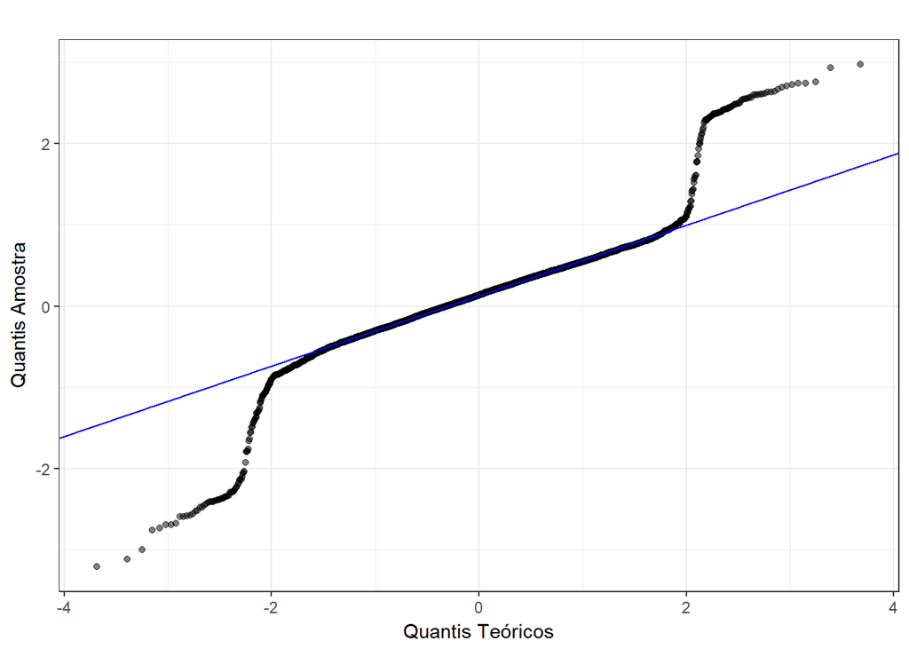

```r
ggQQ(errosMQO)
```

```r
# Altura e largura são em inches, default = 7
pdf(file="C:\\Users\\Aishameriane\\Dropbox\\TCC Aisha\\Texto TCC\\TCC\\Figuras\\Fig-4.015.pdf", width = 6, height = 3)
ggQQ(errosMQO)
dev.off()
```

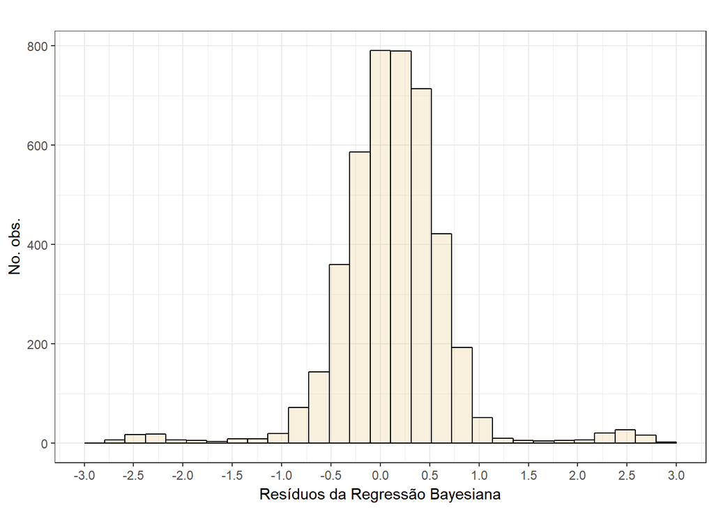

```r
# Histogramas

d <- data.frame(resids = errosbayes)
p1 <- ggplot(data = d, aes(d[,1])) +
  geom_histogram(aes(y = ..count..),
                 alpha = .2, colour = "black", fill = "#dfba56") +
  ggtitle("") +
  labs(title="", y = "No. obs.", x= "Resíduos da Regressão Bayesiana") +
  scale_x_continuous(breaks = seq(-3, 3, 0.5),
                        limits = c(-3,3)) +
  scale_colour_brewer(palette="Dark2") +
  theme_bw()

p1
```

```r
# Altura e largura são em inches, default = 7
pdf(file="C:\\Users\\Aishameriane\\Dropbox\\TCC Aisha\\Texto TCC\\TCC\\Figuras\\Fig-4.012.pdf", width = 6, height = 3)
p1
dev.off()
```

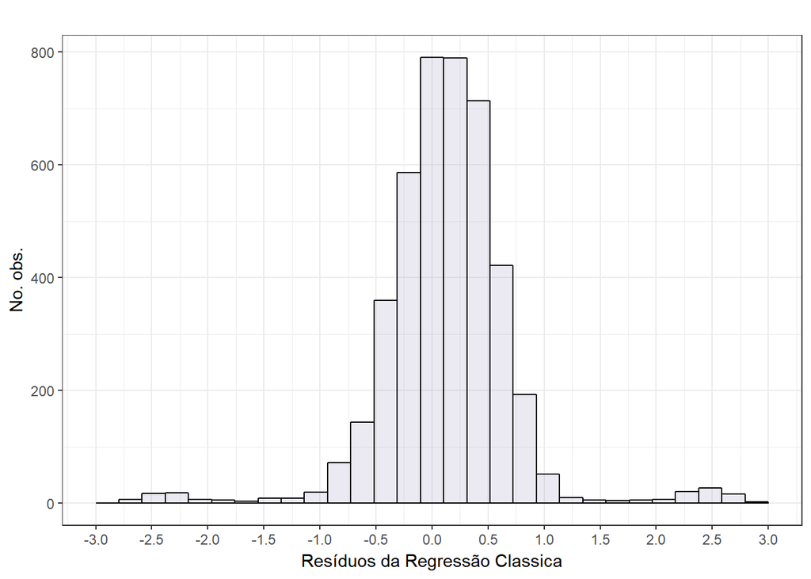

```r
d <- data.frame(resids = errosMQO)
p1 <- ggplot(data = d, aes(d[,1])) +
  geom_histogram(aes(y = ..count..),
                 alpha = .2, colour = "black", fill = "#9a96bf") +
  ggtitle("") +
  labs(title="", y = "No. obs.", x= "Resíduos da Regressão Classica") +
  scale_x_continuous(breaks = seq(-3, 3, 0.5),
                        limits = c(-3,3)) +
  scale_colour_brewer(palette="Dark2") +
  theme_bw()

p1
```

```r
# Altura e largura são em inches, default = 7
pdf(file="C:\\Users\\Aishameriane\\Dropbox\\TCC Aisha\\Texto TCC\\TCC\\Figuras\\Fig-4.013.pdf", width = 6, height = 3)
p1
dev.off()
```